# Week 7: Machine Learning 1

SECU0050

Bennett Kleinberg

27 Feb 2020

Data Science for Crime Scientists

## Week 7: Machine Learning 1

## Machine learning?

- core idea: a system learns from experience
- no precise instructions

## Today

- supervised learning
- core algorithms
- performance metrics

## Supervised learning

- who is the supervisor?
- supervised = labelled data
- i.e. you know the outcome
- flipped logic

## Simulated data

| account | tweet_freq |
| --- | --- |
| bot | 33.7960 |
| bot | 34.5973 |
| bot | 34.2955 |
| bot | 32.2615 |
| real | 19.1904 |
| real | 14.4237 |
| real | 37.6143 |
| real | 29.0793 |

## How to best separate the data into two groups?

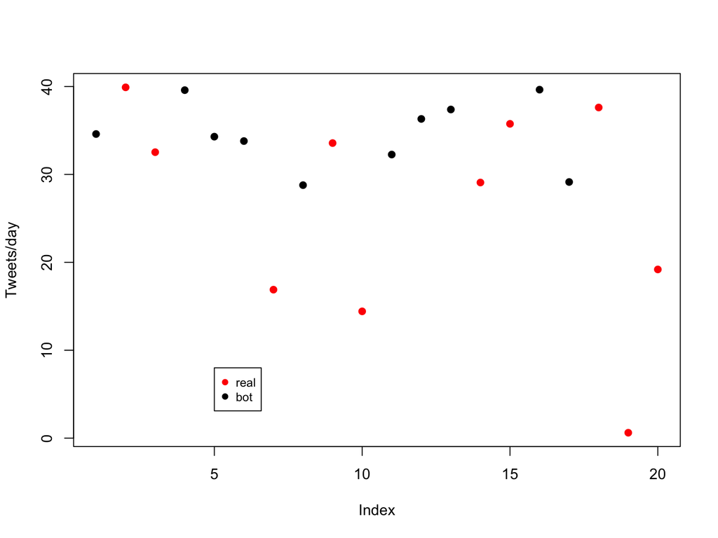

## Core idea

- learn relationship between
  - outcome (target) variable
  - features (predictors)
- “learning” is done through an algorithm
  - simplest algorithm: `if A then B`

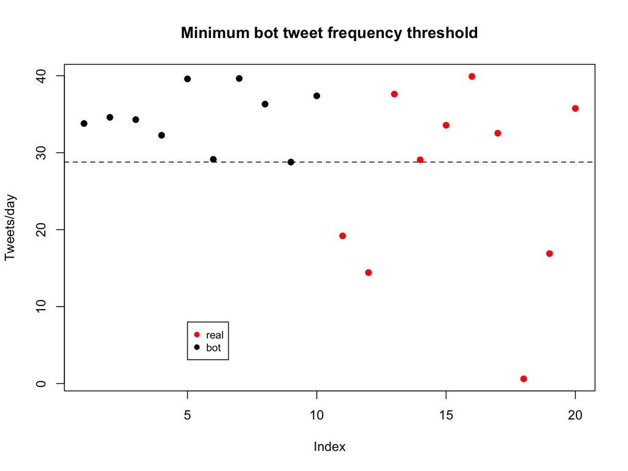

## Higher dimensional data

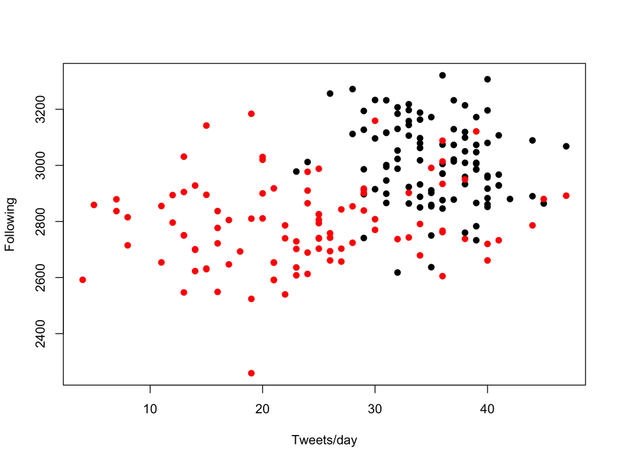

```r
set.seed(123457)
data2 = data.frame(account = rep(c('bot', 'real'), each=100)
                   , tweet_freq = round(c(rnorm(100, 35, 5), rnorm(100, 25, 10)), 0)
                   , following = round(c(rnorm(100, 3000, 150), rnorm(100, 2800, 150)), 0))
data3 = data2
plot(data2$tweet_freq, data2$following, col=data2$account
     , pch=19
     , xlab = 'Tweets/day'
     , ylab = 'Following')
```

## Idea 2: hand-crafted rules

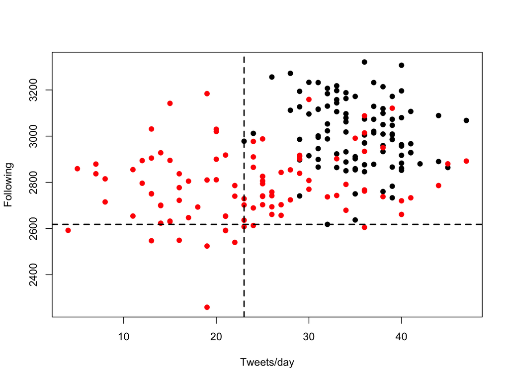

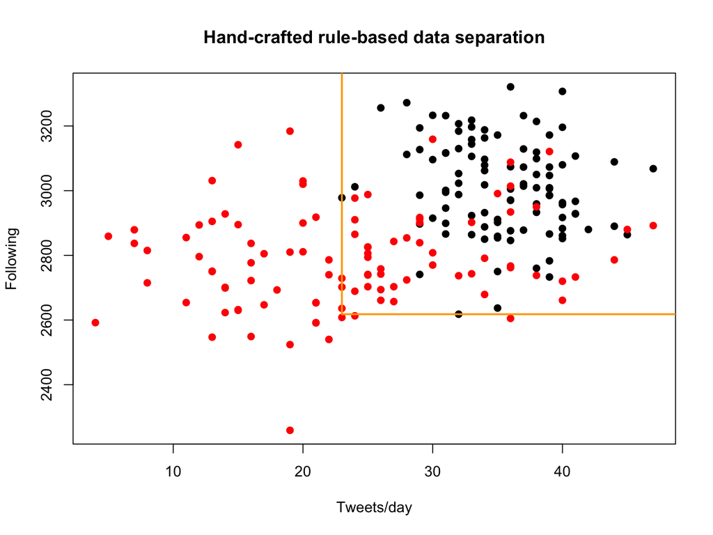

```r
plot(data2$tweet_freq, data2$following, col=data2$account
     , pch=19
     , xlab = 'Tweets/day'
     , ylab = 'Following'
     , main = 'Hand-crafted rule-based data separation')
segments(min(data2$tweet_freq[data2$account == 'bot'])
         , min(data2$following[data2$account == 'bot'])
         , min(data2$tweet_freq[data2$account == 'bot'])
         , 4000, col='orange', lwd=2, lty=1)
segments(min(data2$tweet_freq[data2$account == 'bot'])
         , min(data2$following[data2$account == 'bot'])
         , 50
         , min(data2$following[data2$account == 'bot'])
         , col='orange', lwd=2, lty=1)
```

## But this is not learning

- often we have no idea about the relationships
- too many predictors
- too diverse a problem
- simply unknown

## Stepwise supervised ML

- clarify what `outcome` and `features` are
- determine which classification algorithm to use
- train the model

## Classes of supervised learning

- classification (e.g. death/alive, fake/real)
- regression (e.g. income, number of deaths)

## Core aim of supervised learning

*Learning* from data to **make predictions** about the future.

```r
my_first_model = glm(account ~ .
                       , data = data2
                       , family = 'binomial'
                       )
```

We have trained a model.

= you have taught an algorithm to learn to predict real vs bot accounts based on followers and tweet frequency

[figure not shown]

## Explanatory vs predictive modelling

- this is where you would stop in explanatory modelling
- e.g. interpreting the coefficients
- predictive modelling focuses on the use of that model

## Putting your model to use

```r
data2$model_predictions = predict(my_first_model, data2, type = 'response')
data2$model_1 = ifelse(data2$model_predictions >= .5, 'real', 'bot')
```

|  | bot | real |
| --- | --- | --- |
| bot | 90 | 10 |
| real | 14 | 86 |

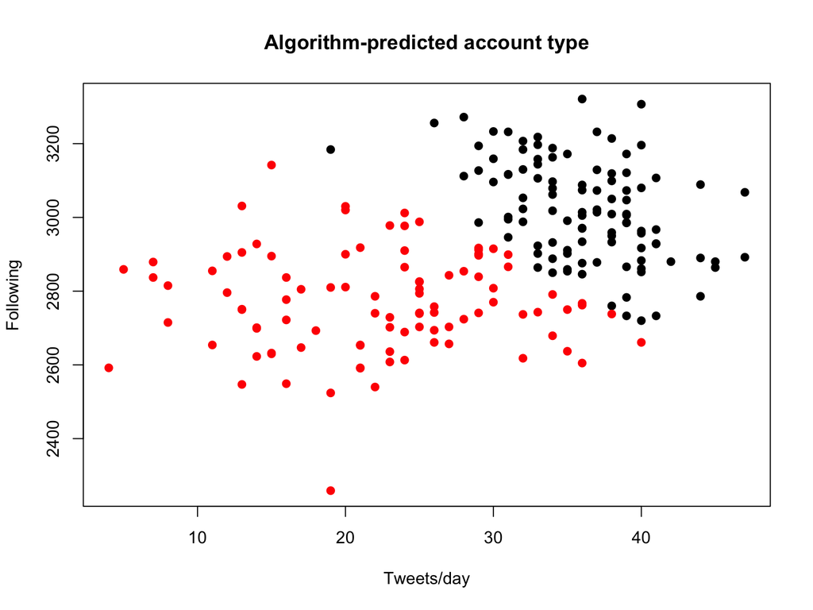

### The key challenge?

Think about what we did

## Problem of inductive bias

- remember: we learn from the data
- but what we really want to know is: how does it work on “unseen” data
- this is needed to estimate how good real predictions would be

How to solve this?

## Splitting the data

- split the data (e.g. 80%/20%, 60%/40%)
- use one part as TRAINING SET
- use the other as TEST SET

## Enter: `caret`

```r
library(caret)
```

- excellent package for ML in R
- well-documented [website](https://topepo.github.io/caret/index.html)
- common interface for [200+ models](https://topepo.github.io/caret/available-models.html)

## `caret`: data partitioning

```r
set.seed(1)
in_training = createDataPartition(y = data3$account
                                  , p = .8
                                  , list = FALSE
                                  )
```

## Creating a training and test set

```r
training_data = data3[ in_training,]
test_data = data3[-in_training,]
```

## Supervised ML steps revised

- define outcome
- define features
- build model on the TRAINING SET
- evaluate model on the TEST SET

## Building an SVM model

```r
my_second_model = train(account ~ .
                       , data = training_data
                       , method = "svmLinear"
                       )
```

## Fit/test the SVM:

```r
model_predictions = predict(my_second_model, test_data)
```

|  | bot | real |
| --- | --- | --- |
| bot | 19 | 1 |
| real | 4 | 16 |

## But!

- our model might be really dependent on the training data
- we want to be more careful

Can we do some kind of safeguarding in the training data?

## Cross-validation

K-fold cross-validation

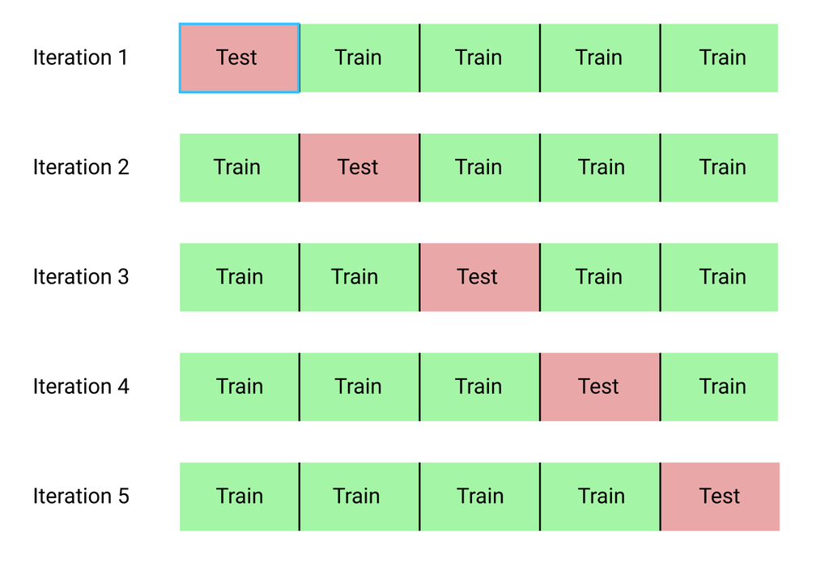

[img source](https://my.oschina.net/Bettyty/blog/751627)

## Specifying CV in `caret`

```r
training_controls = trainControl(method="cv"
                                 , number = 4
                                 , classProbs = TRUE
                                 )

my_third_model = train(account ~ .
                       , data = training_data
                       , trControl = training_controls
                       , method = "svmLinear"
                       )
```

```r
my_third_model
```

```
## Support Vector Machines with Linear Kernel
##
## 160 samples
##   2 predictor
##   2 classes: 'bot', 'real'
##
## No pre-processing
## Resampling: Cross-Validated (4 fold)
## Summary of sample sizes: 120, 120, 120, 120
## Resampling results:
##
##   Accuracy  Kappa
##   0.85      0.7
##
## Tuning parameter 'C' was held constant at a value of 1
```

## Assess the CVed model

```r
model_predictions = predict(my_third_model, test_data)
```

|  | bot | real |
| --- | --- | --- |
| bot | 19 | 1 |
| real | 4 | 16 |

## Algorithm in detail

Naive Bayes

- rooted in Bayes’ theorem
- closely related to Bayesian inference
- important for classification
- often used in NLP

## Bayes rule

$P(A|B) = \frac{P(B|A)*P(A)}{P(B)}$

In ML we are interested in:

$P(outcome|data) = \frac{P(data|outcome)*P(outcome)}{P(data)}$

Our scenario: text classification (normal vs spam email)

## Data

| id | outcome | “cash” | “rich” | “gmail” | “happy” |
| --- | --- | --- | --- | --- | --- |
| 1 | normal | 1 | 0 | 1 | 1 |
| 2 | normal | 0 | 0 | 1 | 0 |
| 3 | spam | 1 | 0 | 0 | 0 |
| 4 | spam | 1 | 1 | 0 | 0 |

## Problem in Bayes terms

$P(spam|text) = \frac{P(text|spam)*P(spam)}{P(text)}$

What we know:

- $P(spam) = \frac{2}{4} = 0.5$ (prior of outcome)
- $P(text)$ is a constant (prior of data)

## Needed: likelihood

$P(text|spam) = P(word_1|spam) * P(word_2|spam) ... P(word_n|spam)$

- $P('cash'|spam) = \frac{'cash'_{spam}}{'cash'_{total}} = \frac{2}{3} = 0.67$

## What is $P('gmail'|spam)$

| id | outcome | “gmail” |
| --- | --- | --- |
| 1 | normal | 1 |
| 2 | normal | 1 |
| 3 | spam | 0 |
| 4 | spam | 0 |

## Problem of zero probabilities

$P('gmail'|spam) = \frac{0}{2} = 0.00$

Results in zero for the whole of:

$P(text|spam) = P(word_1|spam) * P(word_2|spam) ... P(word_n|spam)$

## Laplace smoothing

$P('gmail'|spam) = \frac{'gmail'_{spam} + \alpha}{'gmail'_{total} + \alpha*k}$

For: $\alpha = 1$ and $k = 2$ (= no. of outcomes):

$P('gmail'|spam) = \frac{1}{4} = 0.25$

## We end up with a model

For any new next, we can use $P(spam|text)$ to estimate whether it is spam or not.

### Performance metrics

## Suppose we have two models

```r
svm_model = train(account ~ .
                  , data = training_data
                  , trControl = training_controls
                  , method = "svmLinear"
                  )

nb_model = train(account ~ .
                  , data = training_data
                  , trControl = training_controls
                  , method = "nb"
                  )
```

## Test set results

SVM model

|  | bot | real |
| --- | --- | --- |
| bot | 96 | 104 |
| real | 102 | 98 |

```r
knitr::kable(table(test_data$account, nb_pred), caption = 'NB model')
```

NB model

|  | bot | real |
| --- | --- | --- |
| bot | 124 | 76 |
| real | 140 | 60 |

## The confusion matrix

|  | Bot | Real |
| --- | --- | --- |
| Bot | True positives | False negatives |
| Real | False positives | True negatives |

## False (true) positives (negatives)

- true positives (TP): correctly identified bots
- true negatives (TN): correctly identified real accounts
- false positives (FP): false accusations
- false negatives (FN): missed bots

## Most intuitive: accuracy

$acc=\frac{(TP+TN)}{N}$

Any problems with that?

## Accuracy

Model 1

|  | Bot | Real |
| --- | --- | --- |
| Bot | 100 | 100 |
| Real | 5 | 195 |

Model 2

|  | Bot | Real |
| --- | --- | --- |
| Bot | 150 | 50 |
| Real | 55 | 145 |

## Problem with accuracy

- same accuracy, different confusion matrix
- relies on thresholding idea
- not suitable for comparing models (don’t be fooled by the literature!!)

Needed: more nuanced metrics

## Beyond accuracy

```
##        prediction
## reality Bot Real Sum
##    Bot  100  100 200
##    Real   5  195 200
##    Sum  105  295 400
```

```
##        prediction
## reality Bot Real Sum
##    Bot  150   50 200
##    Real  55  145 200
##    Sum  205  195 400
```

## Precision

i.e. –> how often the prediction is correct when prediction class *X*

Note: we have two classes, so we get *two* precision values

Formally:

- $Pr_{bot} = \frac{TP}{(TP+FP)}$
- $Pr_{real} = \frac{TN}{(TN+FN)}$

## Precision

```
##        prediction
## reality Bot Real Sum
##    Bot  100  100 200
##    Real   5  195 200
##    Sum  105  295 400
```

## Comparing the models

[output not shown]

## Recall

i.e. –> how many of class *X* is detected

Note: we have two classes, so we get *two* recall values

Also called sensitivity and specificity!

Formally:

- $R_{bot} = \frac{TP}{(TP+FN)}$
- $R_{real} = \frac{TN}{(TN+FP)}$

## Recall

```
##        prediction
## reality Bot Real Sum
##    Bot  100  100 200
##    Real   5  195 200
##    Sum  105  295 400
```

- $R_{bot} = \frac{100}{200} = 0.50$
- $R_{real} = \frac{195}{200} = 0.98$

## Comparing the models

[output not shown]

## Combining Pr and R

The *F1* measure.

Note: we combine Pr and R for each class, so we get *two* F1 measures.

Formally:

- $F1_{bot} = 2*\frac{Pr_{bot} * R_{bot}}{Pr_{bot} + R_{bot}}$
- $F1_{real} = 2*\frac{Pr_{real} * R_{real}}{Pr_{real} + R_{real}}$

## F1 measure

```
##        prediction
## reality Bot Real Sum
##    Bot  100  100 200
##    Real   5  195 200
##    Sum  105  295 400
```

## Comparing the models

[output not shown]

## In caret

```r
confusionMatrix(nb_pred, as.factor(test_data$account))
```

```
## Confusion Matrix and Statistics
##
##           Reference
## Prediction bot real
##       bot  124  140
##       real  76   60
##
##                Accuracy : 0.46
##                  95% CI : (0.4104, 0.5102)
##     No Information Rate : 0.5
##     P-Value [Acc > NIR] : 0.9506
##
##                   Kappa : -0.08
##  Mcnemar's Test P-Value : 1.814e-05
##
##             Sensitivity : 0.6200
##             Specificity : 0.3000
##          Pos Pred Value : 0.4697
##          Neg Pred Value : 0.4412
##              Prevalence : 0.5000
##          Detection Rate : 0.3100
##    Detection Prevalence : 0.6600
##       Balanced Accuracy : 0.4600
##
##        'Positive' Class : bot
##
```

## There’s more

What’s behind the model’s predictions?

## Class probabilities

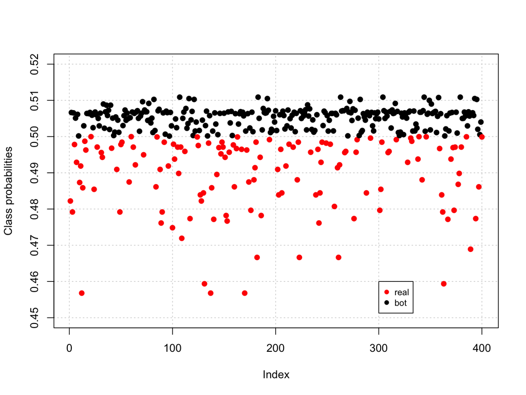

## The threshold problem

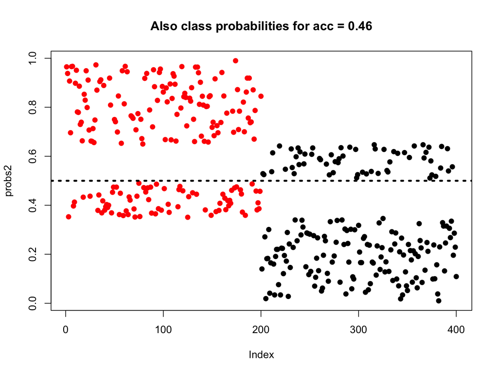

## Issue!

- classification threshold little informative
- obscures certainty in judgment

Needed: a representation across all possible values

## The Area Under the Curve (AUC)

- plot all observed values (here: class probs)
- y-axis: sensitivity
- x-axis: 1-specificity

## AUC step-wise

```r
#for each class probability:
threshold_1 = probs[1]
threshold_1
```

```
## [1] 0.4822156
```

```r
pred_threshold_1 = ifelse(probs >= threshold_1, 'bot', 'real')
```

|  | bot | real |
| --- | --- | --- |
| bot | 183 | 17 |
| real | 188 | 12 |

## Sensitivity and 1-Specificity

|  | bot | real |
| --- | --- | --- |
| bot | 183 | 17 |
| real | 188 | 12 |

$Sens. = 183/200 = 0.92$

$Spec. = 12/200 = 0.06$

$Sens. = 183/200 = 0.92$

$Spec. = 12/200 = 0.06$

| Threshold | Sens. | 1-Spec |
| --- | --- | --- |
| 0.48 | 0.92 | 0.94 |

Do this for every threshold observed.

## Plot the results:

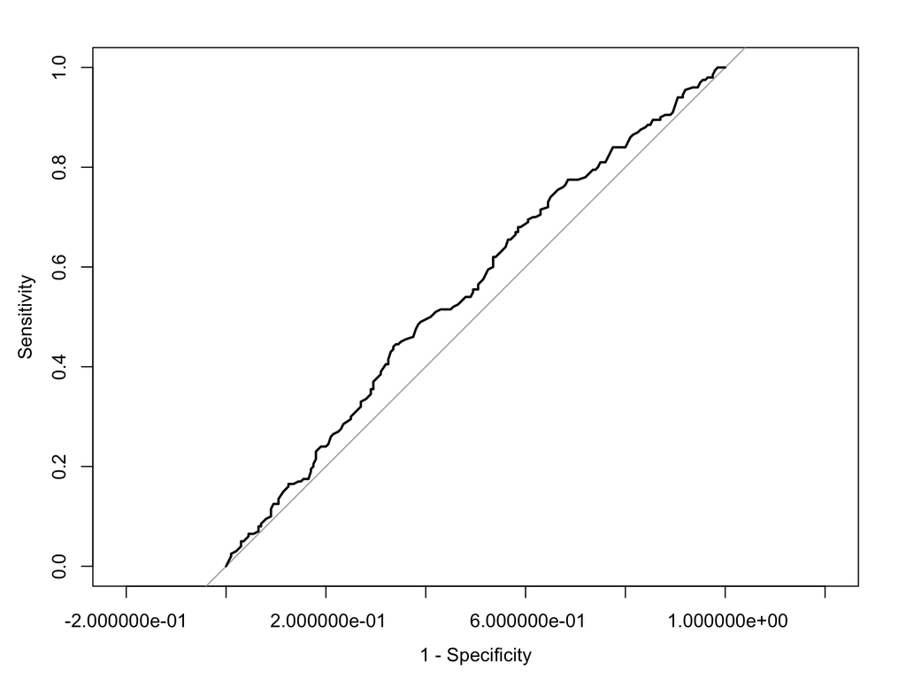

## Quantify this plot

```r
auc1 = roc(response = test_data$account
               , predictor = probs
               , ci=T)
auc1
```

```
##
## Call:
## roc.default(response = test_data$account, predictor = probs,     ci = T)
##
## Data: probs in 200 controls (test_data$account bot) < 200 cases (test_data$account real).
## Area under the curve: 0.5534
## 95% CI: 0.4971-0.6098 (DeLong)
```

## What if we compare our two models?

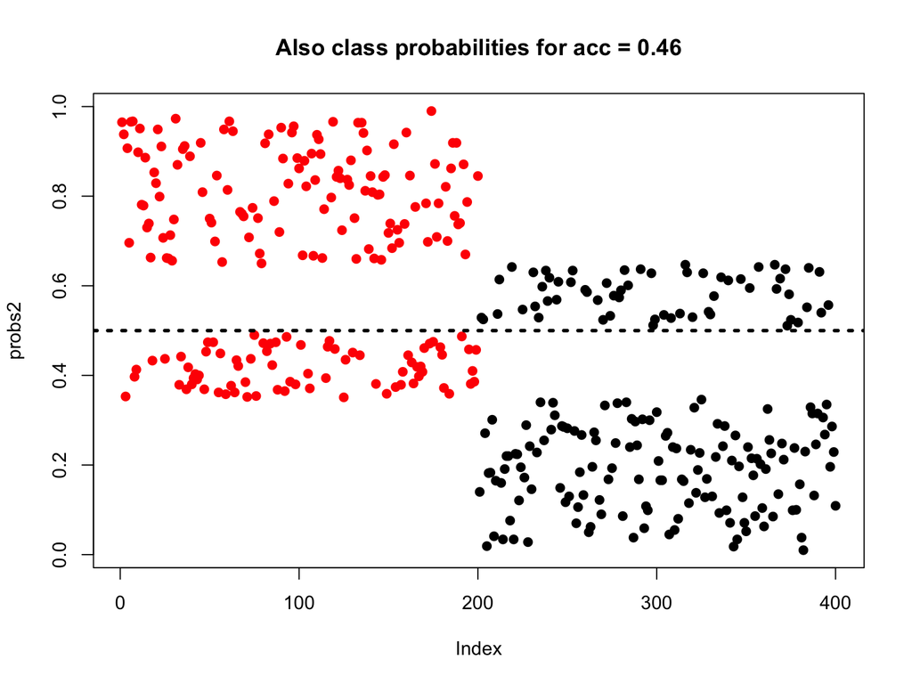

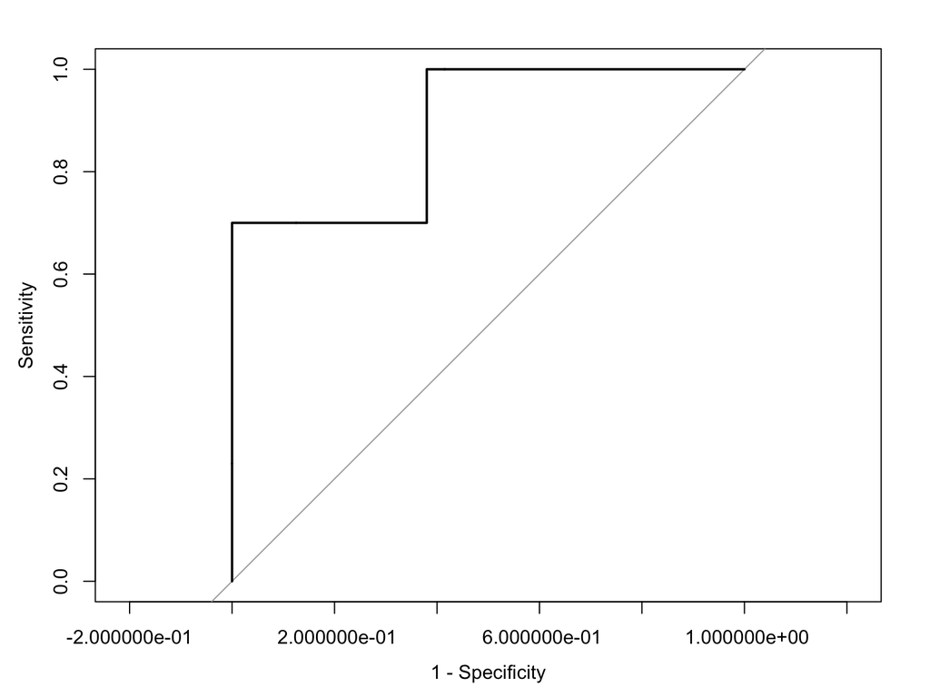

```r
auc2 = roc(response = test_data$account
               , predictor = probs2
               , ci=T)

plot.roc(auc2, xlim=c(1, 0), legacy.axes = T)
```

## What’s next?

- Today’s tutorial + homework: text classification, performance metrics

Next week: Machine Learning 2